# Introduction to the `hpiR` package

Andy Krause

2020-04-01

### Introduction

This vignette provides an introduction to using the `hpiR` package for estimating house price indexes. At the current time, this package (version 0.3.0) offers three approaches to estimating house price indexes – repeat transactions, hedonic price models and random forest (with post-model interpretability). Future versions will incorporate additional methodological options. More information on this package’s development can be found at www.github.com/andykrause/hpiR

A detailed explanation of the class and method structure employed in this package can be found in the **Classes in hpiR** vignette in this package, or at: https://github.com/andykrause/hpiR/blob/master/vignettes/classstructure.Rmd

#### Terminology

A bit of terminology:

- **Index**: a time-series of values estimating tracking the movement of prices over time with a base period value of 100
- **Series**: progression of increasing longer indexes
- **Model**: statistical or other type of mathematical equation or algorithm used to generate the raw coefficient (or other) estimates that are converted into the scaled (base = 100) index values
- **Accuracy**: ability of an index to represent the actual market movements
- **Volatility**: measure of the period to period movement in index values
- **Smooth**: reduce volatility with a rolling average or similar smoothing process
- **Revision**: amount that the index value for a specific period moves over the course of a **series**

In general, this vignette takes the following path through the functionality provided by `hpiR` as this is imagined to most closely approximate a real-world application of the package to real estate market data.

1. **Data preparation**
2. **Modeling**
3. **Index creation**
4. **Analysis: Index-level**
5. **Series creation**
6. **Analysis: Series-level**

### Load Package

Begin by loading the `hpiR` packages (assuming that you’ve already downloaded it from: www.github.com/andykrause/hpiR or from CRAN (forthcoming).

```r
  library(hpiR)
```

### Data

This package provides two sample datasets to work with. The first, `seattle_sales`, includes over 43,000 sales of single family homes and townhouses within the City of Seattle over the 2010 to 2016 time frame. The second, `ex_sales` is a subset of the first, encompassing only the central area of the city. The source of the data is the King County Assessor’s office.[^1] The data is open and free to share.

The data can be loaded with the `data(seattle_sales)` and `data(ex_sales)` commands. We will work with the `ex_sales` object in this vignette.

```r
  data(seattle_sales)
  data(ex_sales)
```

All potential models, indexes and series that can be created with `hpiR` require the transaction date to be converted to a numeric and relative time period. Relative, here, means relative to the base period which is assumed to be the first period in the transaction data (though this can be changed by the user).

The `dateToPeriod()` function will convert R date fields into relative time periods based on a periodicity of choice. The available periodicity options are:

- *“yearly”*
- *“quarterly”*
- *“monthly”*
- *“weekly”*

with *“yearly”* as the default. In addition to the transaction data (`trans_df`) and the period type selection (`periodicity`), the `dateToPeriod()` function also requires an input telling it which field in the data contains the transaction date (`date`).

```r
  sales_hdf <- dateToPeriod(trans_df = ex_sales,
                            date = 'sale_date',
                            periodicity = 'monthly')
```

```r
  salesx_hdf <- dateToPeriod(trans_df = ex_sales,
                            date = 'sale_date',
                            periodicity = 'monthly',
                            min_date = as.Date('2009-12-01'),
                            max_date = as.Date('2016-12-31'))
## Your choice of periodicity resulted in 1 empty periods out of 85 total periods.
```

If the dates that are provided as alternative minimums and maximums are within the range of transaction dates in the data, there are two options to what can happen. The first, and default, is that the minimums and maximums will be adjusted to be the actual minimum and maximum dates in the transactions. A warning will let you know that this has happened.

```r
  salesx_hdf <- dateToPeriod(trans_df = ex_sales,
                            date = 'sale_date',
                            periodicity = 'monthly',
                            min_date = as.Date('2010-12-01'),
                            max_date = as.Date('2015-12-31'))
## Supplied "min_date" is greater than minimum of transactions. Adjusting.
## Supplied "max_date" is less than maximum of transactions. Adjusting.
```

Alternatively, you can use the `min_date` and `max_date` arguments to “clip”" your dataset to a particular time frame by setting `adj_type = "clip"`. The default, `adj_type = "move"`, simply moves it to the minimum or maximum in the data as shown above. The clipping functionality allows you to create an index for a subset of the time period covered by your data.

```r
  sales_hdf_clip <- dateToPeriod(trans_df = ex_sales,
                                 date = 'sale_date',
                                 periodicity = 'monthly',
                                 min_date = as.Date('2010-12-01'),
                                 max_date = as.Date('2015-12-31'),
                                 adj_type = 'clip')
## Supplied "min_date" date is greater than minimum of transactions. Clipping transactions.
## Supplied "max_date" is less than maximum of transactions. Clipping transactions.
```

For the sake of the remainder of this analysis, let’s allow the defaults to set the time boundaries based on the data itself (we will use the `sales_hdf` object going forward).

We now have a dataset that includes two new, standardized fields (`trans_date` and `trans_period`) indicating the date of transaction and the period of each transaction relative to the first transaction in the data (at a monthly periodicity), respectively. Note that these standardized fields are required for the processes that follow.

Additional information on the full extent of the periods as well as their numeric and date values can be found in the `"period_table"` attribute of the `sales_hdf` object or accessed by:

```r
  head(attr(sales_hdf, 'period_table'))
```

```
##       name  numeric period
## 1 2010-Jan 2010.000      1
## 2 2010-Feb 2010.083      2
## 3 2010-Mar 2010.167      3
## 4 2010-Apr 2010.250      4
## 5 2010-May 2010.333      5
## 6 2010-Jun 2010.417      6
```

Finally, information on the minimum date, maximum date and the periodicity can also be found in the attributes of `hpidata` objects.

### Repeat Transactions (Sales) Model

Let’s start by creating an index using a repeat-transactions model (often referred to as a repeat-sales or a sale-resale model), one of the most popular approaches to create a house price index.

#### Data Prep

First, we use the `rtCreateTrans()` function to convert the transaction data (the `hpidata` object) into a `data.frame` of repeat transactions (properties that have transacted multiple times in the 2010 to 2016 period.) The `rtCreateTrans()` function requires a unique property id field, a unique transaction id field and a field denoting the transaction price. The `min_period_dist` parameter ensure that no ‘flips’ are included in the dataset by limiting the data to only those sales 12 periods (one year) or more apart.

```r
  sales_rtdf <- rtCreateTrans(trans_df = sales_hdf,
                              prop_id = 'pinx',
                              trans_id = 'sale_id',
                              price = 'sale_price',
                              min_period_dist = 12)
```

This function creates a `data.frame` with eight fields: the property id, the time period for the first transaction and the second transaction, the prices for the two transactions, the unique transaction ids for both and a unique id for the pair. The resulting object has a class of `rtdata` (inheriting from `hpidata` and `data.frame`).

| prop_id | period_1 | period_2 | price_1 | price_2 | trans_id1 | trans_id2 | pair_id |
| --- | --- | --- | --- | --- | --- | --- | --- |
| ..0007600057 | 56 | 80 | 520000 | 625000 | 2014..23738 | 2016..28612 | 1 |
| ..0216000010 | 29 | 47 | 1063000 | 1300000 | 2012..12112 | 2013..36837 | 2 |
| ..0342000250 | 40 | 78 | 626800 | 751000 | 2013..11548 | 2016..17781 | 3 |
| ..0342000570 | 15 | 57 | 295000 | 429000 | 2011..4885 | 2014..27574 | 4 |
| ..0342000570 | 15 | 78 | 295000 | 607000 | 2011..4885 | 2016..18557 | 5 |
| ..0342000570 | 57 | 78 | 429000 | 607000 | 2014..27574 | 2016..18557 | 6 |

In the event of more than two transactions of the same property, all pairs of transactions are created by default – sales 1 to 2, 1 to 3 and 2 to 3. If you’d like to only use sequential transactions as pairs – sales 1 to 2 and 2 to 3, for example – you can set `seq_only = TRUE` (default is FALSE).

```r
  sales_rtdf_so <- rtCreateTrans(trans_df = sales_hdf,
                                 prop_id = 'pinx',
                                 trans_id = 'sale_id',
                                 price = 'sale_price',
                                 seq_only = TRUE)
```

| prop_id | period_1 | period_2 | price_1 | price_2 | trans_id1 | trans_id2 | pair_id |
| --- | --- | --- | --- | --- | --- | --- | --- |
| ..0007600057 | 56 | 80 | 520000 | 625000 | 2014..23738 | 2016..28612 | 1 |
| ..0216000010 | 29 | 47 | 1063000 | 1300000 | 2012..12112 | 2013..36837 | 2 |
| ..0342000250 | 40 | 78 | 626800 | 751000 | 2013..11548 | 2016..17781 | 3 |
| ..0342000570 | 15 | 57 | 295000 | 429000 | 2011..4885 | 2014..27574 | 4 |
| ..0342000570 | 57 | 78 | 429000 | 607000 | 2014..27574 | 2016..18557 | 5 |
| ..0345000485 | 8 | 31 | 622000 | 517000 | 2010..15338 | 2012..17939 | 6 |

#### Modeling

Next, we use the `rtdata` object to estimate a repeat transactions model. In this simple example we will use the *“base”* estimator (a simple OLS) with a logged dependent variable (`log_dep = TRUE`). Models may also be estimated via a robust regression model (`estimator = "robust"`) or a weighted OLS model (`estimator = "weighted"`) as originally suggested by Case and Shiller (1987).

The `hpiModel()` function is an S3 method that will dispatch on the class of the object that is passed to its `hpi_df` argument. In this case that class is `rtdata` signifying that the data is in repeat-transaction format. Again, we’ll use a base estimator here with a logged dependent variable. The `hpiModel()` function returns an object of class `hpimodel` that includes the full regression model results, extracted and cleaned coefficients as well as additional information on the approach.

```r
  rt_model <- hpiModel(model_type = 'rt',
                       hpi_df = sales_rtdf,
                       estimator = 'base',
                       log_dep = TRUE)
```

The objects created by regression models can be rather large, so by default the `hpiModel()` function trims some of the unnecessary results from the model estimation function(s). If you want full results you can set `trim_model = FALSE`.

```r
  rt_full <- hpiModel(model_type = 'rt',
                      hpi_df = sales_rtdf,
                      estimator = 'base',
                      log_dep = TRUE,
                      trim_model = FALSE)

  object.size(rt_model)
## 509448 bytes
  object.size(rt_full)
## 925304 bytes
```

#### Index Creation

We can then convert model results into an index with the `modelToIndex()` function. The output of this function is an object of class `hpiindex`, which has a time-series object ($value slot, class `ts`) with an index value (base = 100) for each of the time periods estimated. Note that no smoothing is done at this time.

```r
  rt_index <- modelToIndex(model_obj = rt_model)
```

If you want to limit the extent of the index (clip periods from the end of it) you can set the `max_period` argument within the `modelToIndex()` function to the last period you wish to have in the index.

```r
  rt_short <- modelToIndex(model_obj = rt_model,
                           max_period = 50)
  length(rt_short$value)
```

```
## [1] 50
```

A simple plot (with the `plot.hpiindex()` method) shows the results of this estimation.

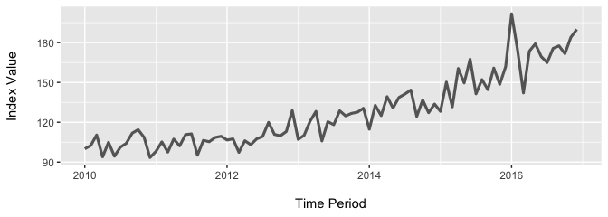

```r
  plot(rt_index)
```

In situations where there are empty periods in the modeling results (there was no or not enough data to estimate a value for a particular period), the `modelToIndex()` will impute (using the `imputeTS` package) the missing periods. For missing periods at the start of the index or before the first non-100 period, all periods are given a value of 100. For missing internal periods (those with estimated periods both before and after) a ‘stine’ interpolation is used and for those missing at the end a ‘last observation carried forward’ (LOCF) approach is used. The `\$imputed` slot in the `hpiindex` object will indicate which periods have been imputed.

```r
  rt_model_imp <- rt_full
  rt_model_imp$coefficients$coefficient[3:5] <- NA
  rt_index_imp <- modelToIndex(model_obj = rt_model_imp)
## Total of 3 period(s) imputed

  rt_index_imp$value[1:6]
```

```
## [1] 100.00000 102.45339 101.56738  98.36161  95.38765  94.43324
```

```r
  rt_index_imp$imputed[1:6]
```

```
## [1] 0 0 1 1 1 0
```

The plot function can show the imputed periods as well with `show_imputed=TRUE`.

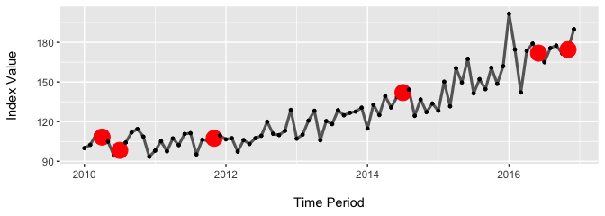

```r
  rt_model_imp <- rt_full
  rt_model_imp$coefficients$coefficient[c(4, 7, 23, 55, 78, 83)] <- NA
  rt_index_imp <- modelToIndex(model_obj = rt_model_imp)
## Total of 6 period(s) imputed

  plot(rt_index_imp, show_imputed=TRUE)
```

#### Smoothing

As we see from the plots of the indexes above, considerable volatility from one period to the next is common. Smoothing of indexes may be warranted as indexes resulting from raw model results often exhibit greater volatility than is actually occurring in the market. The `smoothIndex()` function will smooth via a moving average function, with small corrections to keep index length after smoothing. The amount of smoothing is controlled by the `order` argument – the number of periods over which to smooth. Note that the `order` is saved in the attributes of the `indexsmooth` object.

```r
  rt_smooth <- smoothIndex(index_obj = rt_index,
                           order = 5)
  attr(rt_smooth, 'order')
```

```
## [1] 5
```

The `smoothIndex()` function can be done **‘in_place’** such that the smoothed indexes are added to the larger `hpiindex` object.

```r
   rt_index <- smoothIndex(index_obj = rt_index,
                           order = 7,
                           in_place = TRUE)
   names(rt_index)
```

```
## [1] "name"    "numeric" "period"  "value"   "imputed" "smooth"
```

The **in_place** smoothing can be plotted by adding `smooth=TRUE` to the plot call.

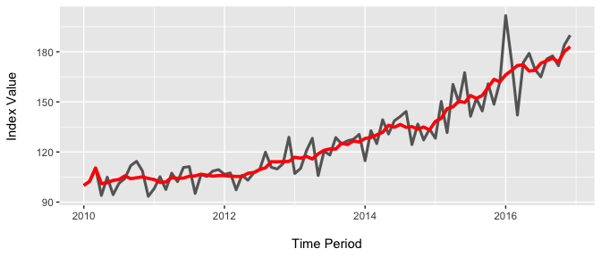

```r
   plot(rt_index, smooth=TRUE)
```

#### Data to Index Wrapper

A wrapper function, `rtIndex()`, will do all of the above taking it from a raw `data.frame` of transaction data through to the repeat transaction index creation and storing all results in a unified object of class `hpi`.

There are three ‘levels of entry’ with the wrapper function.

1. You can give it a raw `data.frame` with your transactions and it will A) Add the periods; B) Calculate the repeat transactions; and C) Model the data and create the index. Under this approach `trans_df` is passed a raw `data.frame` along with the following arguments, some of which are optional (will revert to default if not given) and some of which are required (mostly field names):
   - `periodicity` (optional: default = ‘annual’)
   - `min_date` (optional: default = minimum of data)
   - `max_date` (optional: default = maximum of data)
   - `adj_type` (opt: default = ‘move’)
   - `date` (required)
   - `price` (required)
   - `trans_id` (required)
   - `prop_id` (required)
   - `seq_only` (optional: default = FALSE)
   - `estimator` (optional: default = ‘base’)
   - `log_dep` (optional: default = TRUE)
   - `trim_model` (optional: default = FALSE)
   - `max_period` (optional: default = maximum of index length)
   - `smooth` (optional: default = FALSE)
   - `smooth_order` (optional, default = 3)

```r
  rt_1 <- rtIndex(trans_df = ex_sales,
                  periodicity = 'monthly',
                  min_date = '2010-06-01',
                  max_date = '2015-11-30',
                  adj_type = 'clip',
                  date = 'sale_date',
                  price = 'sale_price',
                  trans_id = 'sale_id',
                  prop_id = 'pinx',
                  seq_only = TRUE,
                  estimator = 'robust',
                  log_dep = TRUE,
                  trim_model = TRUE,
                  max_period = 48,
                  smooth = FALSE)
## Supplied "min_date" date is greater than minimum of transactions. Clipping transactions.
## Supplied "max_date" is less than maximum of transactions. Clipping transactions.
```

2. You can provide a `hpidata` object (one that has been through the `dateToPeriod()` function). In this case, the following arguments are valid:
   - `date` (required)
   - `price` (required)
   - `trans_id` (required)
   - `prop_id` (required)
   - `seq_only` (optional: default = FALSE)
   - `estimator` (optional: default = ‘base’)
   - `log_dep` (optional: default = TRUE)
   - `trim_model` (optional: default = FALSE)
   - `max_period` (optional: default = maximum of index length)
   - `smooth` (optional: default = FALSE)
   - `smooth_order` (optional, default = 3)

```r
  sales_hdf <- dateToPeriod(trans_df = ex_sales,
                            date = 'sale_date',
                            periodicity = 'monthly')
```

```r
  rt_2 <- rtIndex(trans_df = sales_hdf,
                  date = 'sale_date',
                  price = 'sale_price',
                  trans_id = 'sale_id',
                  prop_id = 'pinx',
                  seq_only = FALSE,
                  estimator = 'weighted',
                  log_dep = FALSE,
                  trim_model = FALSE,
                  max_period = 56,
                  smooth = TRUE)
```

3. Finally, you can provide it an `rtdata` object (one that has been through the `rtCreateTrans()` function). Only the following arguments are meaningful in this case.
   - `estimator` (optional: default = ‘base’)
   - `log_dep` (optional: default = TRUE)
   - `trim_model` (optional: default = FALSE)
   - `max_period` (optional: default = maximum of index length)
   - `smooth` (optional: default = FALSE)
   - `smooth_order` (optional, default = 3)

```r
  sales_rtdf <- rtCreateTrans(trans_df = sales_hdf,
                            prop_id = 'pinx',
                            trans_id = 'sale_id',
                            price = 'sale_price')
```

```r
  rt_3 <- rtIndex(trans_df = sales_rtdf,
                  estimator = 'robust',
                  log_dep = TRUE,
                  trim_model = FALSE,
                  max_period = 80,
                  smooth = TRUE,
                  smooth_order = 5)
```

A plot method exists to cleanly plot `hpi` objects.

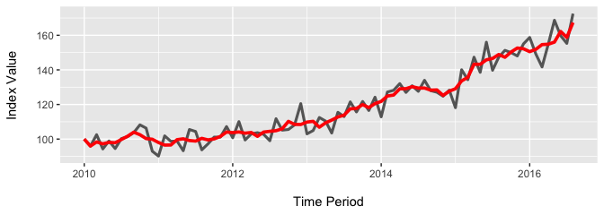

```r
  plot(rt_3, smooth=TRUE)
```

### Hedonic Price Model

Another option for developing a house price index is to use a hedonic price model. Similar to the repeat transaction model presented above, this process can be done stepwise or through a single wrapper function (`hedIndex()`). We’ll start with individual steps.

First, we create a set of hedonic model ready data with the `hedCreateTrans()` function. Here we provide the raw transactions, along with field names for the property id, the transaction ids, the price and date. A periodicity (*“yearly”*, *“quarterly”*, *“monthly”* or *“weekly”*) is also required. Note that this function uses the `dateToPeriod()` discussed above and creates an object of class `heddata` inheriting from `hpidata` and `data.frame`.

```r
  sales_hhdf <- hedCreateTrans(trans_df = ex_sales,
                               prop_id = 'pinx',
                               trans_id = 'sale_id',
                               price = 'sale_price',
                               date= 'sale_date',
                               periodicity = 'monthly')
```

Next, we estimate the hedonic model. There are two ways to specify the model. First, you can provide the dependent variable and independent variable(s) directly, as in the example below. These will simply be combined as a basic linear formula. The `log_dep` argument will control whether or not the dependent variable (`dep_var`) is converted into log format (as is common in hedonic price studies).

```r
  hed_model <- hpiModel(model_type = 'hed',
                        hpi_df = sales_hhdf,
                        estimator = 'base',
                        dep_var = 'price',
                        ind_var = c('tot_sf', 'beds', 'baths'),
                        log_dep = TRUE)
```

```r
  model_spec <- as.formula('log(price) ~ as.factor(baths) + tot_sf')

  hed_model <- hpiModel(model_type = 'hed',
                        hpi_df = sales_hhdf,
                        estimator = 'base',
                        mod_spec = model_spec,
                        log_dep = TRUE)
```

In addition to the base estimator (OLS) there are robust regression (`estimator = "robust"`) and weighted least squares (`estimator = "weighted"`) options.

```r
  hed_model_rob <- hpiModel(model_type = 'hed',
                            hpi_df = sales_hhdf,
                            estimator = 'robust',
                            dep_var = 'price',
                            ind_var = c('tot_sf', 'beds', 'baths'),
                            log_dep = TRUE)
```

Do note that the weighted option requires a vectors of weights.

```r
  hed_model_wgt <- hpiModel(model_type = 'hed',
                            hpi_df = sales_hhdf,
                            estimator = 'weighted',
                            dep_var = 'price',
                            ind_var = c('tot_sf', 'beds', 'baths'),
                            log_dep = FALSE,
                            weights = runif(nrow(sales_hhdf), 0, 1))
```

The output from `hpiModel()` can be converted to an index with the `modelToIndex()` function.

```r
  hed_index <- modelToIndex(model_obj = hed_model)
```

And, again, this can be plotted to shown the index.

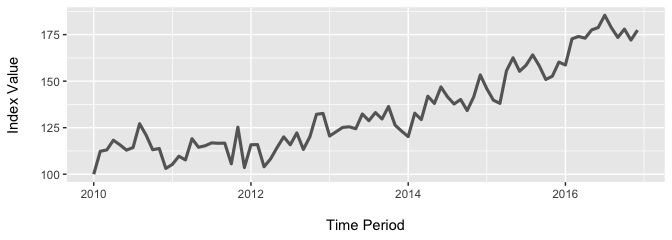

```r
  plot(hed_index)
```

The `hedIndex()` wrapper function will perform all of the above hedonic modeling tasks, and then condense the results into an unified object of class `hpi`.

There are three ‘levels of entry’ with the wrapper function.

1. You can give it a raw `data.frame` with your transactions and it will A) Add the periods; B) Create a hedonic sales object; and 3) Model the data and create the index. Under this approach `trans_df` is passed a raw `data.frame` along with the following arguments, some of which are optional (will revert to default if not given) and some of which are required (mostly field names and the model specification):
   - `periodicity` (optional: default = ‘annual’)
   - `min_date` (optional: default = minimum of data)
   - `max_date` (optional: default = maximum of data)
   - `adj_type` (opt: default = ‘move’)
   - `date` (required)
   - `price` (required)
   - `trans_id` (required)
   - `prop_id` (required)
   - `dep_var` (required, unless `hed_spec` supplied)
   - `ind_var` (required, unless `hed_spec` supplied)
   - `hed_spec` (required, unless `dep_var` and `ind_var` supplied)
   - `estimator` (optional: default = ‘base’)
   - `log_dep` (optional: default = TRUE)
   - `trim_model` (optional: default = FALSE)
   - `max_period` (optional: default = maximum of data)
   - `smooth` (optional: default = FALSE)
   - `smooth_order` (optional, default = 3)

```r
  hed_1 <- hedIndex(trans_df = ex_sales,
                    periodicity = 'monthly',
                    min_date = '2010-06-01',
                    max_date = '2015-11-30',
                    adj_type = 'clip',
                    date = 'sale_date',
                    price = 'sale_price',
                    trans_id = 'sale_id',
                    prop_id = 'pinx',
                    estimator = 'robust',
                    log_dep = TRUE,
                    trim_model = TRUE,
                    max_period = 48,
                    dep_var = 'price',
                    ind_var = c('tot_sf', 'beds', 'baths'),
                    smooth = FALSE)
## Supplied "min_date" date is greater than minimum of transactions. Clipping transactions.
## Supplied "max_date" is less than maximum of transactions. Clipping transactions.
```

2. You can provide an `hpidata` object (one that has been through the `dateToPeriod()` function). In this case, the following arguments are valid:
   - `date` (required)
   - `price` (required)
   - `trans_id` (required)
   - `prop_id` (required)
   - `dep_var` (required, unless `hed_spec` supplied)
   - `ind_var` (required, unless `hed_spec` supplied)
   - `hed_spec` (required, unless `dep_var` and `ind_var` supplied)
   - `estimator` (optional: default = ‘base’)
   - `log_dep` (optional: default = TRUE)
   - `trim_model` (optional: default = FALSE)
   - `max_period` (optional: default = maximum of data)
   - `smooth` (optional: default = FALSE)
   - `smooth_order` (optional, default = 3)

```r
  sales_hdf <- dateToPeriod(trans_df = ex_sales,
                           date = 'sale_date',
                           periodicity = 'monthly',
                           min_date = '2010-02-01',
                           max_date = '2015-11-30',
                           adj_type = 'move')
## Supplied "min_date" is greater than minimum of transactions. Adjusting.
## Supplied "max_date" is less than maximum of transactions. Adjusting.
```

```r
  hed_2 <- hedIndex(trans_df = sales_hdf,
                    date = 'sale_date',
                    price = 'sale_price',
                    trans_id = 'sale_id',
                    prop_id = 'pinx',
                    estimator = 'base',
                    log_dep = FALSE,
                    trim_model = FALSE,
                    max_period = 56,
                    dep_var = 'price',
                    ind_var = c('tot_sf', 'beds', 'baths'),
                    smooth = TRUE)
```

3. Finally, you can provide it an `heddata` object (one that has been through the `hedCreateTrans()` function). Only the following arguments can be given in this case.
   - `dep_var` (required, unless `hed_spec` supplied)
   - `ind_var` (required, unless `hed_spec` supplied)
   - `hed_spec` (required, unless `dep_var` and `ind_var` supplied)
   - `estimator` (optional: default = ‘base’)
   - `log_dep` (optional: default = TRUE)
   - `trim_model` (optional: default = FALSE)
   - `max_period` (optional: default = maximum of data)
   - `smooth` (optional: default = FALSE)
   - `smooth_order` (optional, default = 3)

```r
  sales_hhdf <- hedCreateTrans(trans_df = sales_hdf,
                               prop_id = 'pinx',
                               trans_id = 'sale_id',
                               price = 'sale_price')
```

```r
  hed_3 <- hedIndex(trans_df = sales_hhdf,
                    estimator = 'weighted',
                    log_dep = TRUE,
                    trim_model = FALSE,
                    max_period = 80,
                    dep_var = 'price',
                    ind_var = c('tot_sf', 'beds', 'baths'),
                    weights = runif(nrow(sales_hhdf), 0, 1),
                    smooth = TRUE,
                    smooth_order = 5)
```

Again, we can plot with a simple `plot()` call.

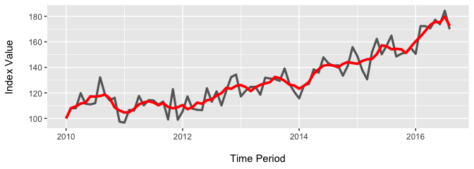

```r
  plot(hed_3, smooth=TRUE)
```

### Analyzing an index

Before we start analyzing our indexes, we’ll create two example `hpi` objects, one using a repeat sales model and one with a hedonic price model.

```r
  rt_hpi <- rtIndex(trans_df = sales_rtdf,
                    estimator = 'robust',
                    log_dep = TRUE,
                    trim_model = FALSE,
                    max_period = 84,
                    smooth = TRUE)

  hed_hpi <- hedIndex(trans_df = sales_hhdf,
                      estimator = 'weighted',
                      log_dep = TRUE,
                      trim_model = FALSE,
                      max_period = 84,
                      dep_var = 'price',
                      ind_var = c('tot_sf', 'beds', 'baths'),
                      weights = runif(nrow(sales_hhdf), 0, 1),
                      smooth = TRUE)
```

#### Volatility

```r
  index_vol <- calcVolatility(index = hed_hpi$index$value,
                              window = 3)
  names(index_vol)
```

```
## [1] "roll"   "mean"   "median"
```

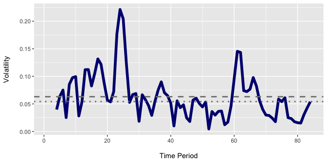

```r
  plot(index_vol)
```

A number of differently classed objects can be passed to the `index` argument in the `calcVolatility()` function. These include the extracted `ts` object from an `hpiindex` object (as done above), the raw `hpiindex` object itself (from `modelToIndex()`), or an `hpi` object from one of the wrappers (`rtIndex()` or `hedIndex()`)

```r
 # hpinindex object
 index_vol <- calcVolatility(index = hed_hpi$index,
                             window = 3)

 # hpi object
 index_vol <- calcVolatility(index = hed_hpi,
                             window = 3)
```

If you want to calculate the volatility of the smoothed index, you need to pass the smoothed index directly or change the `smooth` argument to TRUE (default is false) when passing an `hpiindex` or `hpi` object to `calcVolatility()`. Note, you must make sure that a ‘smoothed’ index exists in the `hpi` or `hpindex` object first.

```r
  # Direct passing
  sindex_vol <- calcVolatility(index = hed_hpi$index$smooth,
                               window = 3)

  # While passing 'hpi' or 'hpiindex'
  sindex_vol <- calcVolatility(index = hed_hpi$index,
                               window = 3,
                               smooth = TRUE)
```

The `calcVolatility()` function can also place the volatility metrics directly into the `hpiindex` object by setting `in_place = TRUE`. If passed an `hpiindex` object, the results will be stored in the `hpiindex` object which is returned. If passed an `hpi` object, the results will be stored in the `hpiindex` object within the `hpi` object which is returned.

```r
   # Add it to the 'hpiindex' object
   hed_hpi$index <- calcVolatility(index = hed_hpi$index,
                                   window = 3,
                                   in_place = TRUE)

   # Add it to the full 'hpi' object (to the hpiindex object)
   hed_hpi <- calcVolatility(index = hed_hpi,
                             window = 3,
                             in_place = TRUE)
```

A volatility analysis of a smoothed index will place it under the **$volatility_smooth** name.

```r
   hed_hpi <- calcVolatility(index = hed_hpi,
                             window = 3,
                             in_place = TRUE,
                             smooth = TRUE)
   names(hed_hpi$index)
```

```
## [1] "name"              "numeric"           "period"
## [4] "value"             "imputed"           "smooth"
## [7] "volatility"        "volatility_smooth"
```

```r
   hed_index <- calcVolatility(index = hed_hpi$index,
                               window = 3,
                               in_place = TRUE,
                               in_place_name = 'vol_3')
   names(hed_index)
```

```
## [1] "name"              "numeric"           "period"
## [4] "value"             "imputed"           "smooth"
## [7] "volatility"        "volatility_smooth" "vol_3"
```

A note on renaming and in place addition. All of the analytical objects that are added – volatility and other below – can be renamed to allow for multiple analyses with different parameters. Smoothed indexes, however, cannot be renamed and must be stored under the name ‘smooth’ because all of the analytical process depend on identifying this named slot.